# Projeto análise suicídio

Lucas Vinicius

2022-12-23

# Analisando dados sobre o suicídio

Esse dataset foi retirado de: https://www.kaggle.com/datasets/russellyates88/suicide-rates-overview-1985-to-2016 onde mostra mortes por suicídios de vários países de 1985 até 2016. Nesse projeto respondo algumas perguntas usando gráfico e código em R.

**Ferramentas usadas**: R,Tidyverse,Readr, Ggplot2 e Dplyr

## Perguntas respondidas

1. Quais gerações cometeram mais suicídios?
2. Algum gênero cometeu mais suicídio que outro?
3. Países com maior taxa de suicídio?
4. Idades que mais cometeram suicídio?

## 1.Gerações

```r
# importando library e dataset
library(tidyverse)
library(readr)
df <- read.csv("/home/lucasv/Documents/analise_suicidio/master.csv")

# dim nos mostra quantas linhas e colunas o dataset possuim
dim(df)
```

```
## [1] 27820    12
```

```r
# verificando variaveis
glimpse(df)
```

```
## Rows: 27,820
## Columns: 12
## $ country            <chr> "Albania", "Albania", "Albania", "Albania", "Albani…
## $ year               <int> 1987, 1987, 1987, 1987, 1987, 1987, 1987, 1987, 198…
## $ sex                <chr> "male", "male", "female", "male", "male", "female",…
## $ age                <chr> "15-24 years", "35-54 years", "15-24 years", "75+ y…
## $ suicides_no        <int> 21, 16, 14, 1, 9, 1, 6, 4, 1, 0, 0, 0, 2, 17, 1, 14…
## $ population         <int> 312900, 308000, 289700, 21800, 274300, 35600, 27880…
## $ suicides.100k.pop  <dbl> 6.71, 5.19, 4.83, 4.59, 3.28, 2.81, 2.15, 1.56, 0.7…
## $ country.year       <chr> "Albania1987", "Albania1987", "Albania1987", "Alban…
## $ HDI.for.year       <dbl> NA, NA, NA, NA, NA, NA, NA, NA, NA, NA, NA, NA, NA,…
## $ gdp_for_year....   <chr> "2,156,624,900", "2,156,624,900", "2,156,624,900", …
## $ gdp_per_capita.... <int> 796, 796, 796, 796, 796, 796, 796, 796, 796, 796, 7…
## $ generation         <chr> "Generation X", "Silent", "Generation X", "G.I. Gen…
```

```r
# criando query sobre gerações com maiores taxas de suicídio
geracao <- df |>
  group_by(generation) |>
  summarize(
    total = n()
  ) |>
  arrange(desc(total))
```

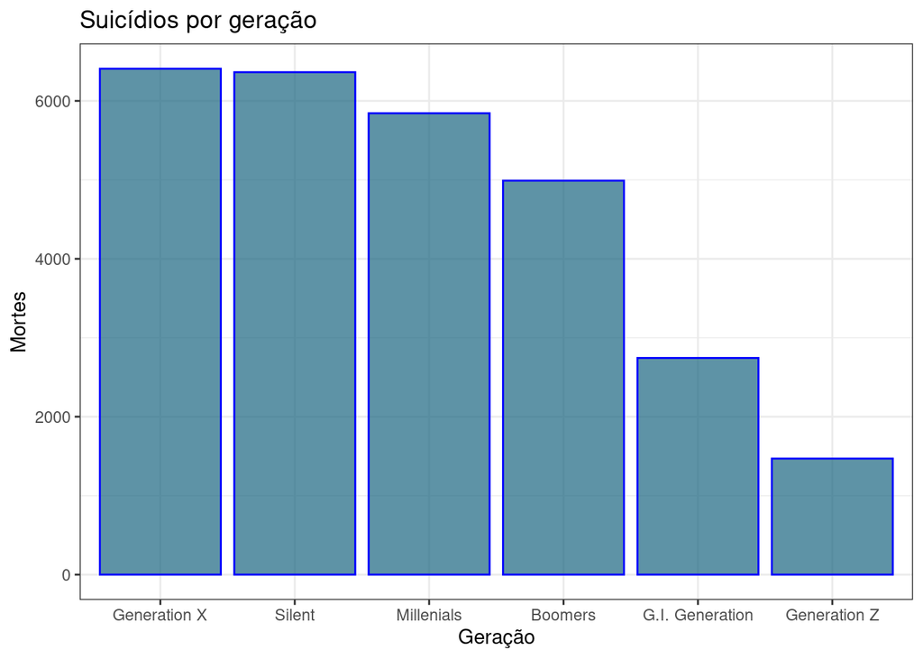

```r
# organizando gerações
geracao$generation <- factor(geracao$generation,
                             levels = c("Generation X","Silent","Millenials",
                                        "Boomers","G.I. Generation","Generation Z"))


# gerando grafico
geracao |>
  ggplot(aes(x=generation, y=total)) +
    geom_bar(color="blue", fill=rgb(0.1,0.4,0.5,0.7),stat = "identity") +
  labs(
    title = "Suicídios por geração",
    x = "Geração",
    y = "Mortes"
  ) +
  theme_bw()
```

## 2.Mortes por gênero

Nosso dataset nos mostra apenas dois gêneros, os demais gêneros não constam ou não possuem dados suficiente.

```r
# buscando todos os gêneros no dataset
df |>
  select(sex) |>
  distinct(sex)
```

```
##      sex
## 1   male
## 2 female
```

```r
# agrupando dados e criando uma relação
generos <- df |>
  group_by(sex) |>
  summarize(
    n_mortes = round(mean(suicides.100k.pop, na.rm = TRUE),2)
  )

# chamando variavel
generos
```

```
## # A tibble: 2 × 2
##   sex    n_mortes
##   <chr>     <dbl>
## 1 female     5.39
## 2 male      20.2
```

Representando esse número em gráfico:

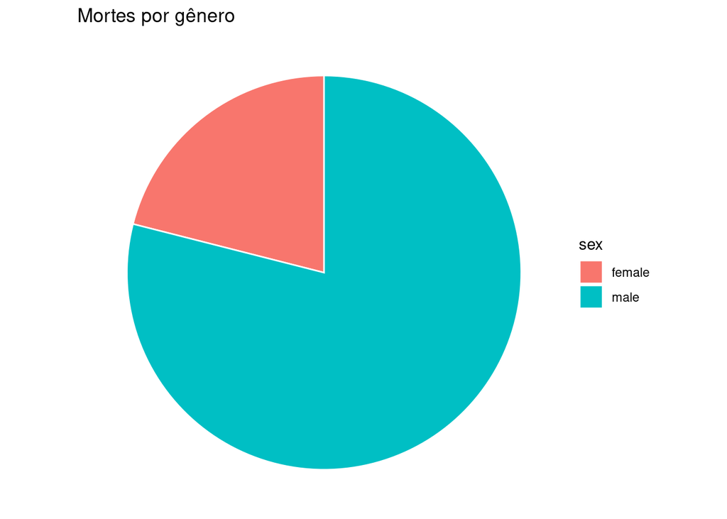

```r
# criando gráfico
ggplot(generos, aes(x="", y=n_mortes, fill=sex)) +
  geom_bar(stat="identity", width=1, color="white") +
  coord_polar("y", start=0) +
  theme_void() +
  labs(
    title = "Mortes por gênero"
  )
```

Com este gráfico podemos responder a segunda pergunta, o gênero masculino cometeu mais suicídios que o gênero feminino.

## 3.Mortes por país

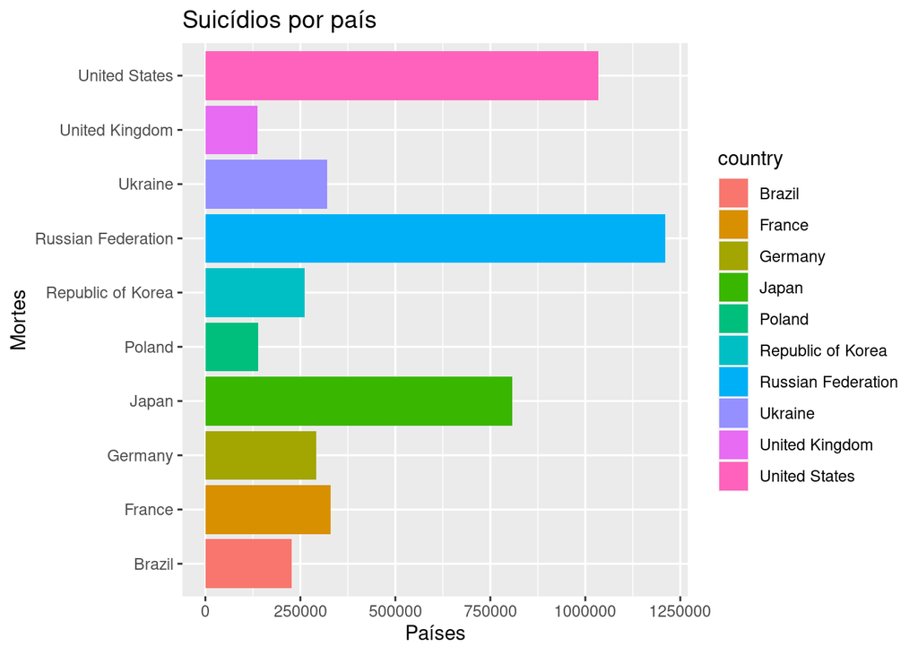

```r
# criando query e atribuindo a uma variavel
paises <- df |>
  group_by(country) |>
  summarize(
    mortes = sum(suicides_no, na.rm = TRUE)
  ) |>
  arrange(desc(mortes))

# deixando apenas os 10 primeiros países
paises <- head(paises,10)

# plotando gráfico
paises |>
  ggplot(aes(x = country,y = mortes, fill = country)) +
  geom_bar(stat = "identity") +
  coord_flip() +
  labs(
    title = "Suicídios por país",
    x = "Mortes",
    y = "Países"
  )
```

A Russia foi o país que mais cometeu suicídio, entre 1985 até 2016.

## 4.Idades que cometeram suicídio

[output not shown]

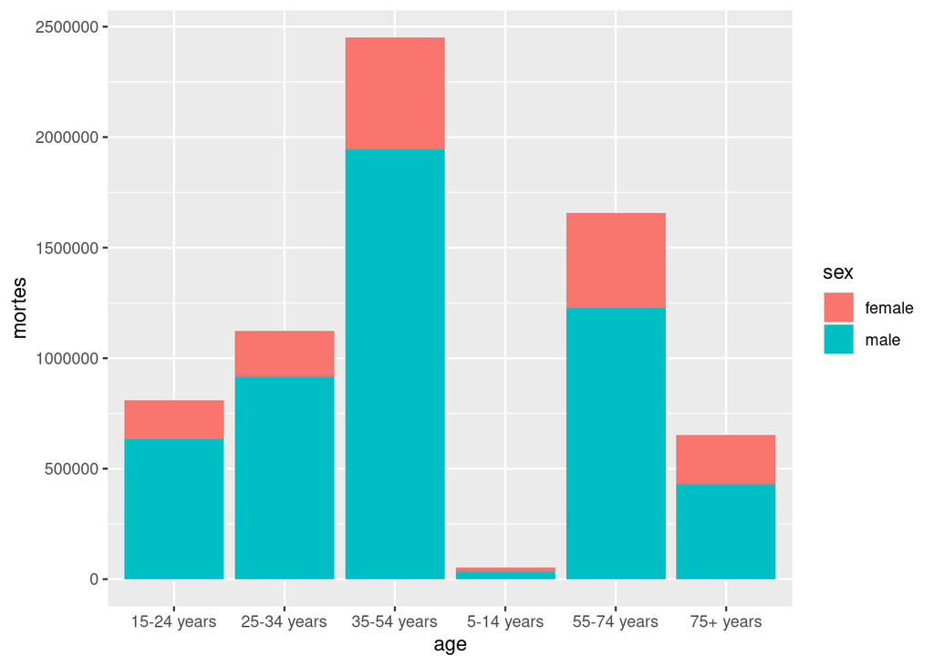

```r
# criando variavel com idade e sexo agrupados
df |>
  group_by(age, sex) |>
  summarize(
    mortes = sum(suicides_no, na.rm = TRUE)
  ) |>
  arrange(desc(mortes)) |>
  ggplot(aes(x = age, y = mortes, fill = sex)) +
  geom_bar(stat = "identity") # plotando o gráfico
```

O gráfico mostra que a maior taxa de mortes por suicídio acontece na classe de 35-54 anos, já a menor classe com taxa de suicídio seria de 5-14 anos de idade.